dikarenakan data testing ada didalam data training, maka kita tidak akan menggunakan data testing yang sudah di sediakan, melainkan kita akan memakai data testing hasil dari train_test_split nanti

# Data Preprocessing

```python
import pandas as pd
import numpy as np
import seaborn as sns
import matplotlib.pyplot as plt
```

```python
dftrain = pd.read_csv('train.csv', delimiter = ';')
```

```python
# from google.colab import drive
# drive.mount('/content/drive')
```

```python
dftrain.head()
```

|  | age | job | marital | education | default | balance | housing | loan | contact | day | month | duration | campaign | pdays | previous | poutcome | y |
| --- | --- | --- | --- | --- | --- | --- | --- | --- | --- | --- | --- | --- | --- | --- | --- | --- | --- |
| 0 | 58 | management | married | tertiary | no | 2143 | yes | no | unknown | 5 | may | 261 | 1 | -1 | 0 | unknown | no |
| 1 | 44 | technician | single | secondary | no | 29 | yes | no | unknown | 5 | may | 151 | 1 | -1 | 0 | unknown | no |
| 2 | 33 | entrepreneur | married | secondary | no | 2 | yes | yes | unknown | 5 | may | 76 | 1 | -1 | 0 | unknown | no |
| 3 | 47 | blue-collar | married | unknown | no | 1506 | yes | no | unknown | 5 | may | 92 | 1 | -1 | 0 | unknown | no |
| 4 | 33 | unknown | single | unknown | no | 1 | no | no | unknown | 5 | may | 198 | 1 | -1 | 0 | unknown | no |

```python
dftrain.info()
```

```
<class 'pandas.core.frame.DataFrame'>
RangeIndex: 45211 entries, 0 to 45210
Data columns (total 17 columns):
 #   Column     Non-Null Count  Dtype
---  ------     --------------  -----
 0   age        45211 non-null  int64
 1   job        45211 non-null  object
 2   marital    45211 non-null  object
 3   education  45211 non-null  object
 4   default    45211 non-null  object
 5   balance    45211 non-null  int64
 6   housing    45211 non-null  object
 7   loan       45211 non-null  object
 8   contact    45211 non-null  object
 9   day        45211 non-null  int64
 10  month      45211 non-null  object
 11  duration   45211 non-null  int64
 12  campaign   45211 non-null  int64
 13  pdays      45211 non-null  int64
 14  previous   45211 non-null  int64
 15  poutcome   45211 non-null  object
 16  y          45211 non-null  object
dtypes: int64(7), object(10)
memory usage: 5.9+ MB
```

## 1.Handling Missing Value

```python
dftrain.info()
```

```
<class 'pandas.core.frame.DataFrame'>
RangeIndex: 45211 entries, 0 to 45210
Data columns (total 17 columns):
 #   Column     Non-Null Count  Dtype
---  ------     --------------  -----
 0   age        45211 non-null  int64
 1   job        45211 non-null  object
 2   marital    45211 non-null  object
 3   education  45211 non-null  object
 4   default    45211 non-null  object
 5   balance    45211 non-null  int64
 6   housing    45211 non-null  object
 7   loan       45211 non-null  object
 8   contact    45211 non-null  object
 9   day        45211 non-null  int64
 10  month      45211 non-null  object
 11  duration   45211 non-null  int64
 12  campaign   45211 non-null  int64
 13  pdays      45211 non-null  int64
 14  previous   45211 non-null  int64
 15  poutcome   45211 non-null  object
 16  y          45211 non-null  object
dtypes: int64(7), object(10)
memory usage: 5.9+ MB
```

```python
dftrain.isna().sum()
```

```
age          0
job          0
marital      0
education    0
default      0
balance      0
housing      0
loan         0
contact      0
day          0
month        0
duration     0
campaign     0
pdays        0
previous     0
poutcome     0
y            0
dtype: int64
```

### tidak ada missing value

tapi kita perlu telaah lebih dalam

```python
dftrain.describe()
```

|  | age | balance | day | duration | campaign | pdays | previous |
| --- | --- | --- | --- | --- | --- | --- | --- |
| count | 45211.000000 | 45211.000000 | 45211.000000 | 45211.000000 | 45211.000000 | 45211.000000 | 45211.000000 |
| mean | 40.936210 | 1362.272058 | 15.806419 | 258.163080 | 2.763841 | 40.197828 | 0.580323 |
| std | 10.618762 | 3044.765829 | 8.322476 | 257.527812 | 3.098021 | 100.128746 | 2.303441 |
| min | 18.000000 | -8019.000000 | 1.000000 | 0.000000 | 1.000000 | -1.000000 | 0.000000 |
| 25% | 33.000000 | 72.000000 | 8.000000 | 103.000000 | 1.000000 | -1.000000 | 0.000000 |
| 50% | 39.000000 | 448.000000 | 16.000000 | 180.000000 | 2.000000 | -1.000000 | 0.000000 |
| 75% | 48.000000 | 1428.000000 | 21.000000 | 319.000000 | 3.000000 | -1.000000 | 0.000000 |
| max | 95.000000 | 102127.000000 | 31.000000 | 4918.000000 | 63.000000 | 871.000000 | 275.000000 |

### Invalid Values

kolom duration memiliki nilai 0

```python
dftrain[dftrain['duration']== 0]
```

|  | age | job | marital | education | default | balance | housing | loan | contact | day | month | duration | campaign | pdays | previous | poutcome | y |
| --- | --- | --- | --- | --- | --- | --- | --- | --- | --- | --- | --- | --- | --- | --- | --- | --- | --- |
| 6424 | 53 | management | married | primary | no | 351 | yes | no | unknown | 27 | may | 0 | 4 | -1 | 0 | unknown | no |
| 22937 | 35 | technician | married | secondary | no | 5535 | no | no | cellular | 26 | aug | 0 | 15 | -1 | 0 | unknown | no |
| 36425 | 31 | entrepreneur | married | secondary | no | 162 | yes | yes | cellular | 11 | may | 0 | 2 | -1 | 0 | unknown | no |

terdapat 3 data yang memiliki duration telepon 0, kita akan drop

```python
dftrain = dftrain[~(dftrain['duration'] < 1)]
```

```python
display(
        dftrain[dftrain['duration'] == 0])
```

|  | age | job | marital | education | default | balance | housing | loan | contact | day | month | duration | campaign | pdays | previous | poutcome | y |
| --- | --- | --- | --- | --- | --- | --- | --- | --- | --- | --- | --- | --- | --- | --- | --- | --- | --- |

## 2.Handling Duplicated Data

```python
dftrain.duplicated().sum()
```

```
0
```

### Data tidak ada yang duplicate

## 3.Handle Outliers

```python
dftrain.head()
```

|  | age | job | marital | education | default | balance | housing | loan | contact | day | month | duration | campaign | pdays | previous | poutcome | y |
| --- | --- | --- | --- | --- | --- | --- | --- | --- | --- | --- | --- | --- | --- | --- | --- | --- | --- |
| 0 | 58 | management | married | tertiary | no | 2143 | yes | no | unknown | 5 | may | 261 | 1 | -1 | 0 | unknown | no |
| 1 | 44 | technician | single | secondary | no | 29 | yes | no | unknown | 5 | may | 151 | 1 | -1 | 0 | unknown | no |
| 2 | 33 | entrepreneur | married | secondary | no | 2 | yes | yes | unknown | 5 | may | 76 | 1 | -1 | 0 | unknown | no |
| 3 | 47 | blue-collar | married | unknown | no | 1506 | yes | no | unknown | 5 | may | 92 | 1 | -1 | 0 | unknown | no |
| 4 | 33 | unknown | single | unknown | no | 1 | no | no | unknown | 5 | may | 198 | 1 | -1 | 0 | unknown | no |

```python
dftrain.select_dtypes('int').columns
```

```
Index(['age', 'balance', 'day', 'duration', 'campaign', 'pdays', 'previous'], dtype='object')
```

### Handle outliers (age)

untuk data berdistribusi cukup normal

#### Z-Score

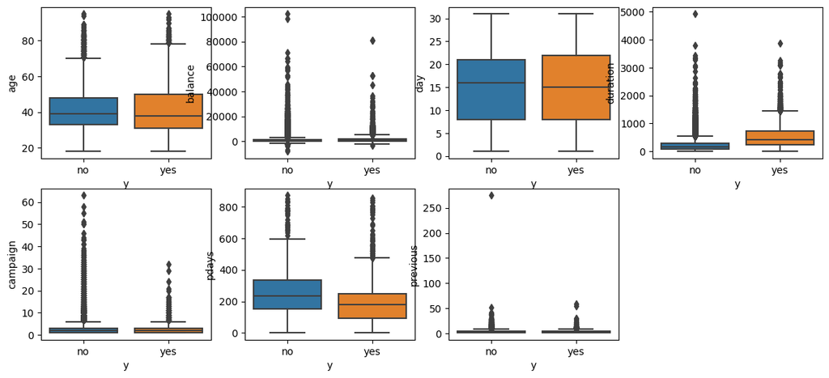

```python
plt.figure(figsize = (14,6))
nums = dftrain.select_dtypes('int').columns
for idx, col in enumerate(nums):
    plt.subplot(2, 4, idx + 1)
    if col == 'pdays':
        ax = sns.boxplot(data = dftrain, y = dftrain[dftrain[col] > -1][col], x = dftrain.y)#, inner = 'box')
    elif col == 'previous':
        ax = sns.boxplot(data = dftrain, y = dftrain[dftrain[col] > 0][col], x = dftrain.y)#, inner = 'box')
    else:
        ax = sns.boxplot(data = dftrain, y = dftrain[col], x = dftrain.y)
```

```python
from scipy import stats
```

```python
print(f'jumlah baris sebelum memfilter outlier: {len(dftrain)}')
filtered_entries = np.array([True] * len(dftrain))
nums = dftrain.select_dtypes('int')

for col in ['age']:
    zscore = abs(stats.zscore(dftrain[col])) #hitung absolute z-scorenya
    filtered_entries = (zscore < 3) #keep yang kurang dari 3 absolute z-scorenya
dftrain = dftrain[filtered_entries] #filter, cuma ambil z-scorenya dibawah 3

print(f'jumlah baris setelah memfilter outlier : {len(dftrain)}')
```

```
jumlah baris sebelum memfilter outlier: 45208
jumlah baris setelah memfilter outlier : 44827
```

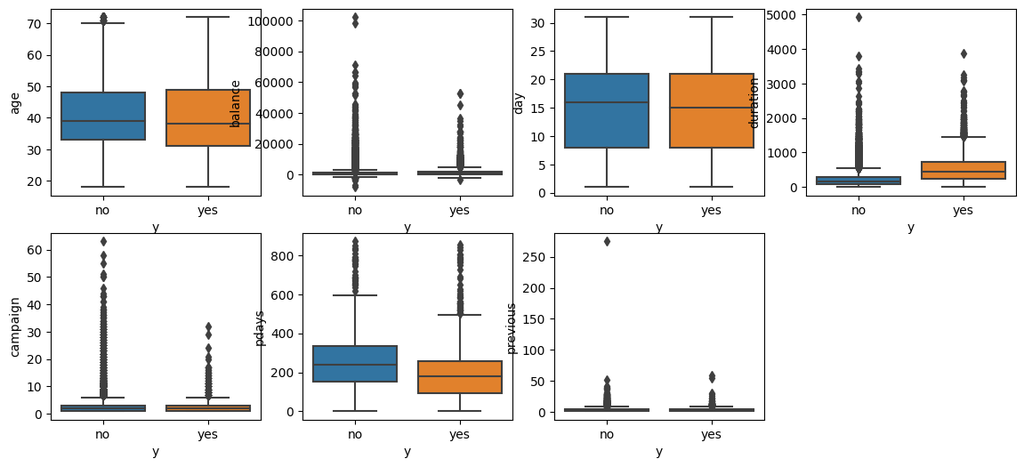

```python
plt.figure(figsize = (14,6))
for idx, col in enumerate(nums):
    plt.subplot(2, 4, idx + 1)
    if col == 'pdays':
        ax = sns.boxplot(data = dftrain, y = dftrain[dftrain[col] > -1][col], x = dftrain.y)#, inner = 'box')
    elif col == 'previous':
        ax = sns.boxplot(data = dftrain, y = dftrain[dftrain[col] > 0][col], x = dftrain.y)#, inner = 'box')
    else:
        ax = sns.boxplot(data = dftrain, y = dftrain[col], x = dftrain.y)
```

### Handle outliers (balance, duration, campaign, pdays, previous)

untuk data yang memiliki nilai ekstrem

#### Percentile

```python
print(f'jumlah baris sebelum memfilter outlier: {len(dftrain)}')
column_to_handle_outliers = ['balance', 'duration', 'campaign', 'pdays', 'previous']
filtered_entries = np.array([True] * len(dftrain))
lower_percentile = 1
upper_percentile = 99

for col in column_to_handle_outliers:
  lower_limit = np.percentile(dftrain[col], lower_percentile)
  upper_limit = np.percentile(dftrain[col], upper_percentile)
  filtered_entries = filtered_entries & ((dftrain[col] >= lower_limit) & (dftrain[col] <= upper_limit))

dftrain = dftrain[filtered_entries]

print(f'jumlah baris setelah memfilter outlier : {len(dftrain)}')
```

```
jumlah baris sebelum memfilter outlier: 44827
jumlah baris setelah memfilter outlier : 41992
```

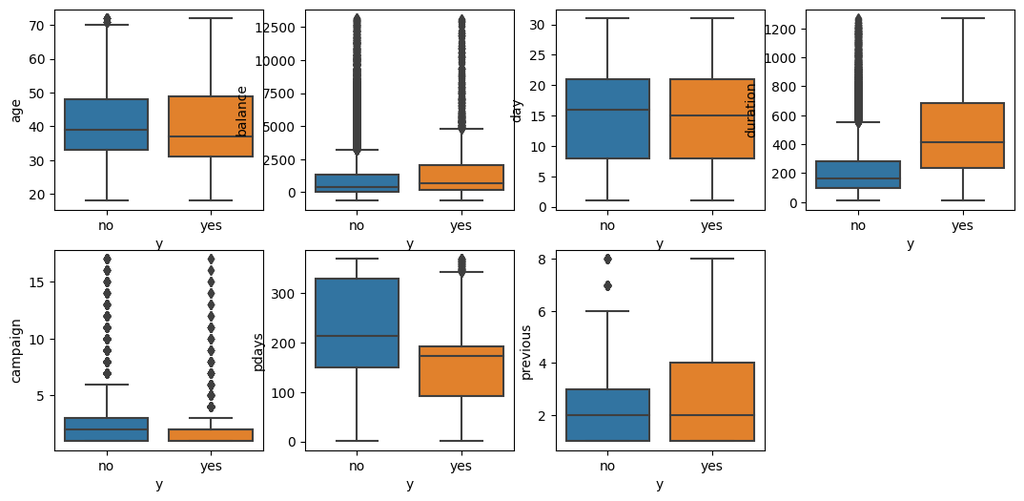

```python
plt.figure(figsize = (13,6))
for idx, col in enumerate(nums):
    plt.subplot(2, 4, idx + 1)
    if col == 'pdays':
        ax = sns.boxplot(data = dftrain, y = dftrain[dftrain[col] > -1][col], x = dftrain.y)#, inner = 'box')
    elif col == 'previous':
        ax = sns.boxplot(data = dftrain, y = dftrain[dftrain[col] > 0][col], x = dftrain.y)#, inner = 'box')
    else:
        ax = sns.boxplot(data = dftrain, y = dftrain[col], x = dftrain.y)
```

#

## 4.Feature Extraction

### Add Age Category

```python
def category_age(age):
    if age < 25:
        return "teenager"
    elif age < 45:
        return "mature"
    else:
        return "elderly"
```

```python
dftrain['age_category'] = dftrain['age'].apply(category_age)
```

### Add Balance Category

```python
# Balance Category
# Hitung Q1 dan Q3
Q1 = dftrain['balance'].quantile(0.25)
Q3 = dftrain['balance'].quantile(0.75)

# Hitung IQR
IQR = Q3 - Q1

# Hitung batas bawah dan batas atas untuk kategori tengah
lower_bound = Q1 + (IQR / 4)
upper_bound = Q3 - (IQR / 4)

# Membagi data dalam DataFrame menjadi tiga kategori
dftrain['balance_category'] = pd.cut(dftrain['balance'], bins=[float('-inf'), lower_bound, upper_bound, float('inf')],
                        labels=['low', 'medium', 'high'])

dftrain.head()
```

|  | age | job | marital | education | default | balance | housing | loan | contact | day | month | duration | campaign | pdays | previous | poutcome | y | age_category | balance_category |
| --- | --- | --- | --- | --- | --- | --- | --- | --- | --- | --- | --- | --- | --- | --- | --- | --- | --- | --- | --- |
| 0 | 58 | management | married | tertiary | no | 2143 | yes | no | unknown | 5 | may | 261 | 1 | -1 | 0 | unknown | no | elderly | high |
| 1 | 44 | technician | single | secondary | no | 29 | yes | no | unknown | 5 | may | 151 | 1 | -1 | 0 | unknown | no | mature | low |
| 2 | 33 | entrepreneur | married | secondary | no | 2 | yes | yes | unknown | 5 | may | 76 | 1 | -1 | 0 | unknown | no | mature | low |
| 3 | 47 | blue-collar | married | unknown | no | 1506 | yes | no | unknown | 5 | may | 92 | 1 | -1 | 0 | unknown | no | elderly | high |
| 4 | 33 | unknown | single | unknown | no | 1 | no | no | unknown | 5 | may | 198 | 1 | -1 | 0 | unknown | no | mature | low |

### Add Category Campaign

```python
# Campaign Category
def category_campaign(campaign):
    if campaign < 5:
        return "low"
    elif campaign < 15:
        return "medium"
    else:
        return "high"
```

```python
dftrain['frequent_campaign'] = dftrain['campaign'].apply(category_campaign)
```

### Add Cost_per_Campaign

```python
# Costs per Campaign
dftrain['cost_per_campaign'] = (dftrain['duration'] * dftrain['campaign'])*(0.395/60)
dftrain.head()
```

|  | age | job | marital | education | default | balance | housing | loan | contact | day | ... | duration | campaign | pdays | previous | poutcome | y | age_category | balance_category | frequent_campaign | cost_per_campaign |
| --- | --- | --- | --- | --- | --- | --- | --- | --- | --- | --- | --- | --- | --- | --- | --- | --- | --- | --- | --- | --- | --- |
| 0 | 58 | management | married | tertiary | no | 2143 | yes | no | unknown | 5 | ... | 261 | 1 | -1 | 0 | unknown | no | elderly | high | low | 1.718250 |
| 1 | 44 | technician | single | secondary | no | 29 | yes | no | unknown | 5 | ... | 151 | 1 | -1 | 0 | unknown | no | mature | low | low | 0.994083 |
| 2 | 33 | entrepreneur | married | secondary | no | 2 | yes | yes | unknown | 5 | ... | 76 | 1 | -1 | 0 | unknown | no | mature | low | low | 0.500333 |
| 3 | 47 | blue-collar | married | unknown | no | 1506 | yes | no | unknown | 5 | ... | 92 | 1 | -1 | 0 | unknown | no | elderly | high | low | 0.605667 |
| 4 | 33 | unknown | single | unknown | no | 1 | no | no | unknown | 5 | ... | 198 | 1 | -1 | 0 | unknown | no | mature | low | low | 1.303500 |

5 rows × 21 columns

## 5.Feature Transformation

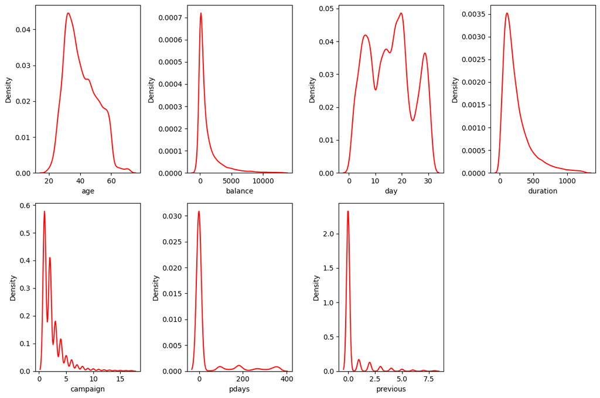

```python
plt.figure(figsize = (12,8))
num = ['age', 'balance', 'day', 'duration', 'campaign', 'pdays', 'previous']
for i in range(0, len(num)):
  plt.subplot(2, 4, i+1)
  sns.kdeplot(dftrain[num[i]], color = 'red')
  plt.tight_layout()
plt.show()
```

### Logarithmic Tranformation

```python
dftrain[['age','duration']] = np.log(dftrain[['age','duration']])
```

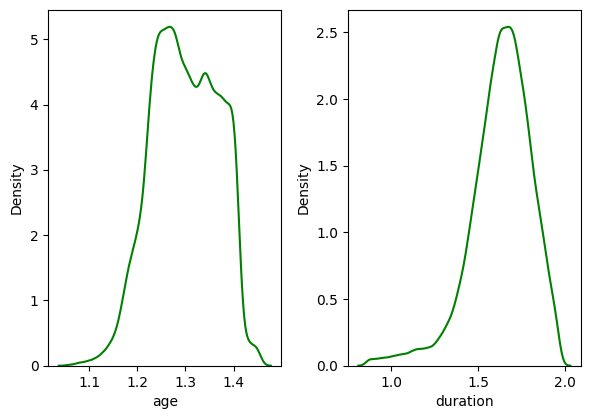

```python
plt.figure(figsize = (12,8))
other = ['age', 'duration']
for i in range(0, len(other)):
  plt.subplot(2, 4, i+1)
  sns.kdeplot(np.log(dftrain[other[i]]), color = 'green')
  plt.tight_layout()
plt.show()
```

### Yeo-Jhonson Transformation

```python
from scipy.stats import boxcox
from scipy.stats import yeojohnson
```

```python
yeojohnson, lambda_optimal = stats.yeojohnson(dftrain['balance'])
dftrain['balance'] = yeojohnson
```

```python
yeojohnson, lambda_optimal = stats.yeojohnson(dftrain['day'])
dftrain['day'] = yeojohnson
```

```python
yeojohnson, lambda_optimal = stats.yeojohnson(dftrain['campaign'])
dftrain['campaign'] = yeojohnson
```

```python
yeojohnson, lambda_optimal = stats.yeojohnson(dftrain['pdays'])
dftrain['pdays'] = yeojohnson
```

```python
yeojohnson, lambda_optimal = stats.yeojohnson(dftrain['previous'])
dftrain['previous'] = yeojohnson
```

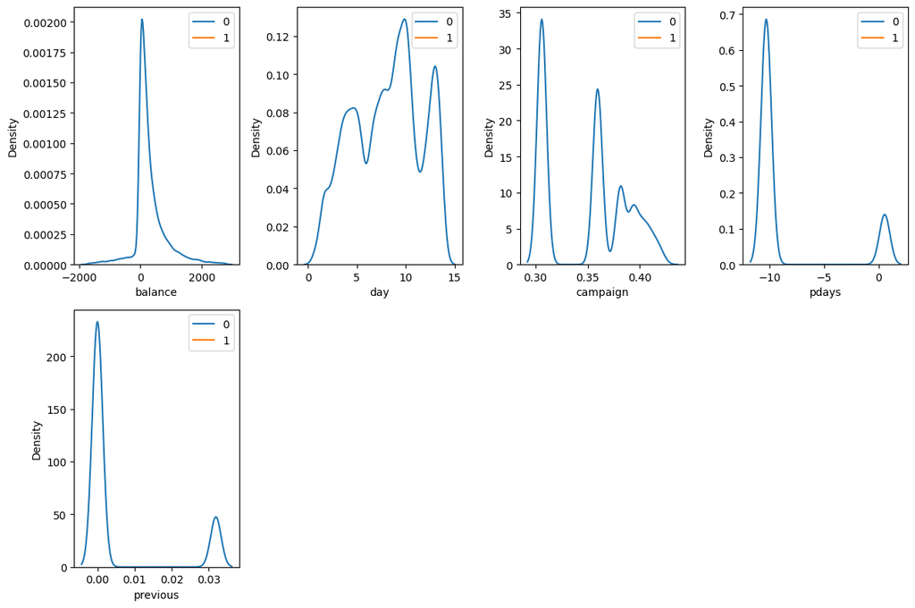

```python
from scipy import stats
other = ['balance', 'day', 'campaign','pdays', 'previous']
plt.figure(figsize = (12,8))
for i in range(0, len(other)):
  plt.subplot(2, 4, i+1)
  sns.kdeplot(stats.yeojohnson(dftrain[other[i]]), color = 'red')
  plt.xlabel(other[i])
  plt.tight_layout()
plt.show()
```

```python
dftrain
```

|  | age | job | marital | education | default | balance | housing | loan | contact | day | ... | duration | campaign | pdays | previous | poutcome | y | age_category | balance_category | frequent_campaign | cost_per_campaign |
| --- | --- | --- | --- | --- | --- | --- | --- | --- | --- | --- | --- | --- | --- | --- | --- | --- | --- | --- | --- | --- | --- |
| 0 | 4.060443 | management | married | tertiary | no | 615.950093 | yes | no | unknown | 3.518552 | ... | 5.564520 | 0.487916 | -1.999640 | -0.000000 | unknown | no | elderly | high | low | 1.718250 |
| 1 | 3.784190 | technician | single | secondary | no | 18.183019 | yes | no | unknown | 3.518552 | ... | 5.017280 | 0.487916 | -1.999640 | -0.000000 | unknown | no | mature | low | low | 0.994083 |
| 2 | 3.496508 | entrepreneur | married | secondary | no | 1.771635 | yes | yes | unknown | 3.518552 | ... | 4.330733 | 0.487916 | -1.999640 | -0.000000 | unknown | no | mature | low | low | 0.500333 |
| 3 | 3.850148 | blue-collar | married | unknown | no | 462.598350 | yes | no | unknown | 3.518552 | ... | 4.521789 | 0.487916 | -1.999640 | -0.000000 | unknown | no | elderly | high | low | 0.605667 |
| 4 | 3.496508 | unknown | single | unknown | no | 0.929967 | no | no | unknown | 3.518552 | ... | 5.288267 | 0.487916 | -1.999640 | -0.000000 | unknown | no | mature | low | low | 1.303500 |
| ... | ... | ... | ... | ... | ... | ... | ... | ... | ... | ... | ... | ... | ... | ... | ... | ... | ... | ... | ... | ... | ... |
| 45205 | 3.218876 | technician | single | secondary | no | 190.344970 | no | yes | cellular | 9.099278 | ... | 5.955837 | 0.643213 | -1.999640 | -0.000000 | unknown | yes | mature | medium | low | 5.082333 |
| 45206 | 3.931826 | technician | married | tertiary | no | 283.727516 | no | no | cellular | 9.099278 | ... | 6.884487 | 0.718692 | -1.999640 | -0.000000 | unknown | yes | elderly | medium | low | 19.295750 |
| 45207 | 4.262680 | retired | divorced | primary | no | 517.470124 | no | no | cellular | 9.099278 | ... | 6.122493 | 0.643213 | -1.999640 | -0.000000 | unknown | yes | elderly | high | low | 6.004000 |
| 45208 | 4.276666 | retired | married | secondary | no | 1364.795416 | no | no | cellular | 9.099278 | ... | 7.027315 | 0.792146 | 1.467899 | 0.206511 | success | yes | elderly | high | medium | 37.097083 |
| 45209 | 4.043051 | blue-collar | married | secondary | no | 238.985110 | no | no | telephone | 9.099278 | ... | 6.230481 | 0.763052 | -1.999640 | -0.000000 | unknown | no | elderly | medium | low | 13.377333 |

41992 rows × 21 columns

## 6.Scaling

```python
from sklearn.preprocessing import MinMaxScaler
```

```python
nums = ['age', 'balance', 'duration', 'campaign', 'day', 'pdays', 'previous']
minmaxscalers = {}
for i in nums:
  minmaxscaler = MinMaxScaler()
  dftrain[i] = minmaxscaler.fit_transform(dftrain[i].values.reshape(-1, 1))

  minmaxscalers[i] = minmaxscaler
```

```python
dftrain
```

|  | age | job | marital | education | default | balance | housing | loan | contact | day | ... | duration | campaign | pdays | previous | poutcome | y | age_category | balance_category | frequent_campaign | cost_per_campaign |
| --- | --- | --- | --- | --- | --- | --- | --- | --- | --- | --- | --- | --- | --- | --- | --- | --- | --- | --- | --- | --- | --- |
| 0 | 0.844028 | management | married | tertiary | no | 0.538427 | yes | no | unknown | 0.197761 | ... | 0.666926 | 0.000000 | 0.000000 | 0.000000 | unknown | no | elderly | high | low | 1.718250 |
| 1 | 0.644753 | technician | single | secondary | no | 0.404942 | yes | no | unknown | 0.197761 | ... | 0.551671 | 0.000000 | 0.000000 | 0.000000 | unknown | no | mature | low | low | 0.994083 |
| 2 | 0.437235 | entrepreneur | married | secondary | no | 0.401277 | yes | yes | unknown | 0.197761 | ... | 0.407077 | 0.000000 | 0.000000 | 0.000000 | unknown | no | mature | low | low | 0.500333 |
| 3 | 0.692332 | blue-collar | married | unknown | no | 0.504183 | yes | no | unknown | 0.197761 | ... | 0.447315 | 0.000000 | 0.000000 | 0.000000 | unknown | no | elderly | high | low | 0.605667 |
| 4 | 0.437235 | unknown | single | unknown | no | 0.401089 | no | no | unknown | 0.197761 | ... | 0.608744 | 0.000000 | 0.000000 | 0.000000 | unknown | no | mature | low | low | 1.303500 |
| ... | ... | ... | ... | ... | ... | ... | ... | ... | ... | ... | ... | ... | ... | ... | ... | ... | ... | ... | ... | ... | ... |
| 45205 | 0.236966 | technician | single | secondary | no | 0.443387 | no | yes | cellular | 0.617137 | ... | 0.749342 | 0.391085 | 0.000000 | 0.000000 | unknown | yes | mature | medium | low | 5.082333 |
| 45206 | 0.751250 | technician | married | tertiary | no | 0.464240 | no | no | cellular | 0.617137 | ... | 0.944926 | 0.581165 | 0.000000 | 0.000000 | unknown | yes | elderly | medium | low | 19.295750 |
| 45207 | 0.989911 | retired | divorced | primary | no | 0.516436 | no | no | cellular | 0.617137 | ... | 0.784441 | 0.391085 | 0.000000 | 0.000000 | unknown | yes | elderly | high | low | 6.004000 |
| 45208 | 1.000000 | retired | married | secondary | no | 0.705649 | no | no | cellular | 0.617137 | ... | 0.975007 | 0.766142 | 0.994879 | 0.998799 | success | yes | elderly | high | medium | 37.097083 |
| 45209 | 0.831483 | blue-collar | married | secondary | no | 0.454248 | no | no | telephone | 0.617137 | ... | 0.807185 | 0.692876 | 0.000000 | 0.000000 | unknown | no | elderly | medium | low | 13.377333 |

41992 rows × 21 columns

```python
dftrain.describe()
```

|  | age | balance | day | duration | campaign | pdays | previous | cost_per_campaign |
| --- | --- | --- | --- | --- | --- | --- | --- | --- |
| count | 41992.000000 | 41992.000000 | 41992.000000 | 41992.000000 | 41992.000000 | 41992.000000 | 41992.000000 | 41992.000000 |
| mean | 0.564723 | 0.464709 | 0.556109 | 0.585239 | 0.341412 | 0.168055 | 0.167072 | 3.933477 |
| std | 0.178794 | 0.112242 | 0.265963 | 0.179164 | 0.309074 | 0.372184 | 0.369963 | 5.538364 |
| min | 0.000000 | 0.000000 | 0.000000 | 0.000000 | 0.000000 | 0.000000 | 0.000000 | 0.072417 |
| 25% | 0.437235 | 0.409912 | 0.317418 | 0.475152 | 0.000000 | 0.000000 | 0.000000 | 1.165250 |
| 50% | 0.557739 | 0.439017 | 0.586698 | 0.588671 | 0.391085 | 0.000000 | 0.000000 | 2.238333 |
| 75% | 0.707519 | 0.496939 | 0.733940 | 0.706532 | 0.581165 | 0.000000 | 0.000000 | 4.509583 |
| max | 1.000000 | 1.000000 | 1.000000 | 1.000000 | 1.000000 | 1.000000 | 1.000000 | 121.765333 |

## 7.Feature Encoding

```python
from sklearn.preprocessing import StandardScaler , LabelEncoder
from sklearn import preprocessing
```

```python
dftrain.head()
```

|  | age | job | marital | education | default | balance | housing | loan | contact | day | ... | duration | campaign | pdays | previous | poutcome | y | age_category | balance_category | frequent_campaign | cost_per_campaign |
| --- | --- | --- | --- | --- | --- | --- | --- | --- | --- | --- | --- | --- | --- | --- | --- | --- | --- | --- | --- | --- | --- |
| 0 | 0.844028 | management | married | tertiary | no | 0.538427 | yes | no | unknown | 0.197761 | ... | 0.666926 | 0.0 | 0.0 | 0.0 | unknown | no | elderly | high | low | 1.718250 |
| 1 | 0.644753 | technician | single | secondary | no | 0.404942 | yes | no | unknown | 0.197761 | ... | 0.551671 | 0.0 | 0.0 | 0.0 | unknown | no | mature | low | low | 0.994083 |
| 2 | 0.437235 | entrepreneur | married | secondary | no | 0.401277 | yes | yes | unknown | 0.197761 | ... | 0.407077 | 0.0 | 0.0 | 0.0 | unknown | no | mature | low | low | 0.500333 |
| 3 | 0.692332 | blue-collar | married | unknown | no | 0.504183 | yes | no | unknown | 0.197761 | ... | 0.447315 | 0.0 | 0.0 | 0.0 | unknown | no | elderly | high | low | 0.605667 |
| 4 | 0.437235 | unknown | single | unknown | no | 0.401089 | no | no | unknown | 0.197761 | ... | 0.608744 | 0.0 | 0.0 | 0.0 | unknown | no | mature | low | low | 1.303500 |

5 rows × 21 columns

### Label Encoder

```python
#Encode kolom menggunakan label encoding
label_encoder = preprocessing.LabelEncoder()
nominal_cols = ['education']
for name in nominal_cols:
  dftrain[name] = label_encoder.fit_transform(dftrain[name])

mapping_dictionary = {"education" : {"tertiary" : 3, "secondary" : 2, "primary" : 1, "unknown" : 0},
                      "default" :{"yes" : 1 , "no" : 0},
                      "housing"  :{"yes" : 1 , "no" : 0},
                      "loan" :{"yes" : 1 , "no" : 0} ,
                      "y" :{"yes" : 1, "no" : 0},
                      "age_category" :{"teenager" : 0, "mature" : 1, "elderly" : 2},
                      "balance_category" : {"low" : 0, "medium": 1, "high" : 2},
                      "frequent_campaign": {"low" : 0, "medium" : 1, "high" : 2}
                      }

dftrain = dftrain.replace(mapping_dictionary)
```

### One Hot Encoding

```python
#encode kolom job, marital, contact, poutcome menggunakan one hot encoding
  #karena datanya tidak bisa di urutkan kastanya dan tidak mengandung yes/no
month = pd.get_dummies(dftrain['month'], prefix = 'month')
job = pd.get_dummies(dftrain['job'], prefix = 'job')
marital = pd.get_dummies(dftrain['marital'], prefix = 'marital_status')
contact = pd.get_dummies(dftrain['contact'], prefix = 'contact_via')
poutcome = pd.get_dummies(dftrain['poutcome'], prefix = 'poutcome')

dftrain = pd.concat([dftrain, job, marital, contact, poutcome, month], axis = 1)
```

```python
dftrain['balance_category'] = dftrain['balance_category'].astype('int')
```

```python
dftrain = dftrain.drop(['job', 'marital', 'contact', 'poutcome', 'month'], axis = 1)
```

```python
dftrain.head()
```

|  | age | education | default | balance | housing | loan | day | duration | campaign | pdays | ... | month_dec | month_feb | month_jan | month_jul | month_jun | month_mar | month_may | month_nov | month_oct | month_sep |
| --- | --- | --- | --- | --- | --- | --- | --- | --- | --- | --- | --- | --- | --- | --- | --- | --- | --- | --- | --- | --- | --- |
| 0 | 0.844028 | 2 | 0 | 0.538427 | 1 | 0 | 0.197761 | 0.666926 | 0.0 | 0.0 | ... | 0 | 0 | 0 | 0 | 0 | 0 | 1 | 0 | 0 | 0 |
| 1 | 0.644753 | 1 | 0 | 0.404942 | 1 | 0 | 0.197761 | 0.551671 | 0.0 | 0.0 | ... | 0 | 0 | 0 | 0 | 0 | 0 | 1 | 0 | 0 | 0 |
| 2 | 0.437235 | 1 | 0 | 0.401277 | 1 | 1 | 0.197761 | 0.407077 | 0.0 | 0.0 | ... | 0 | 0 | 0 | 0 | 0 | 0 | 1 | 0 | 0 | 0 |
| 3 | 0.692332 | 3 | 0 | 0.504183 | 1 | 0 | 0.197761 | 0.447315 | 0.0 | 0.0 | ... | 0 | 0 | 0 | 0 | 0 | 0 | 1 | 0 | 0 | 0 |
| 4 | 0.437235 | 3 | 0 | 0.401089 | 0 | 0 | 0.197761 | 0.608744 | 0.0 | 0.0 | ... | 0 | 0 | 0 | 0 | 0 | 0 | 1 | 0 | 0 | 0 |

5 rows × 50 columns

```python
dftrain.info()
```

```
<class 'pandas.core.frame.DataFrame'>
Int64Index: 41992 entries, 0 to 45209
Data columns (total 50 columns):
 #   Column                   Non-Null Count  Dtype
---  ------                   --------------  -----
 0   age                      41992 non-null  float64
 1   education                41992 non-null  int64
 2   default                  41992 non-null  int64
 3   balance                  41992 non-null  float64
 4   housing                  41992 non-null  int64
 5   loan                     41992 non-null  int64
 6   day                      41992 non-null  float64
 7   duration                 41992 non-null  float64
 8   campaign                 41992 non-null  float64
 9   pdays                    41992 non-null  float64
```

[output cut: 42 more lines]

## 8.Handle Class Imbalance

### Kita akan melakukan Class Imbalance pada tahap modelling nanti menggunakan parameter **Class Weight**

```python
dftrain.shape
```

```
(41992, 50)
```

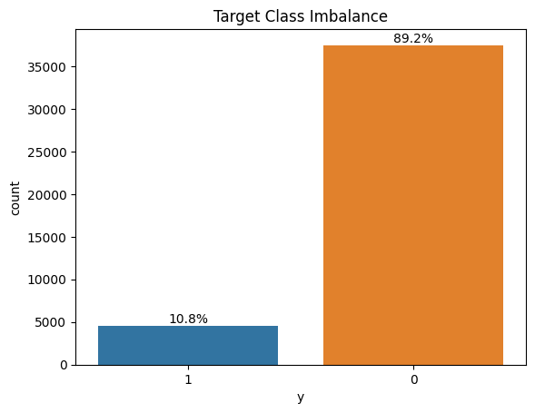

```python
y_order = [1,0]
total_data = len(dftrain['y'])
ax = sns.countplot(data = dftrain, x = 'y', order = y_order)
plt.title("Target Class Imbalance")
for i in ax.patches:
  percentage = '{:.1f}%'.format(100*i.get_height()/total_data)
  x = i.get_x()+i.get_width()/2
  y = i.get_height()
  ax.annotate(percentage, (x,y), ha = 'center', va = 'bottom')
```

```
y
0    132324.493083
1     32850.082833
Name: cost_per_campaign, dtype: float64
85731.50441699999
```

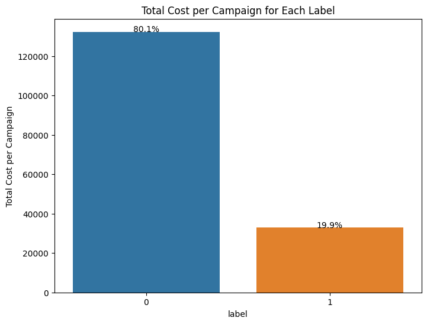

```python
cost = dftrain.groupby("y")['cost_per_campaign'].sum()
total_cost = dftrain['cost_per_campaign'].sum()
percentage_cost = (cost/total_cost) * 100
plot_data = pd.DataFrame({
    'label' : cost.index,
    'total cost' : cost.values,
    'percentage' : percentage_cost.values
})
plt.figure(figsize = (8,6))
print(dftrain.groupby("y")['cost_per_campaign'].sum())
print(117699.624667-31968.120250)
sns.barplot(x = 'label', y = 'total cost', data = plot_data)
plt.xlabel('label')
plt.ylabel('Total Cost per Campaign')
plt.title('Total Cost per Campaign for Each Label')
for i, value in enumerate(plot_data['percentage']):
    plt.text(i, plot_data['total cost'][i] + 5, f'{value:.1f}%', ha='center')

plt.show()
```

# Tahap Data Cleansing Selesai

## 9.Feature Engineering

### Feature Selection

```python
dftrain.info()
```

```
<class 'pandas.core.frame.DataFrame'>
Int64Index: 41992 entries, 0 to 45209
Data columns (total 50 columns):
 #   Column                   Non-Null Count  Dtype
---  ------                   --------------  -----
 0   age                      41992 non-null  float64
 1   education                41992 non-null  int64
 2   default                  41992 non-null  int64
 3   balance                  41992 non-null  float64
 4   housing                  41992 non-null  int64
 5   loan                     41992 non-null  int64
 6   day                      41992 non-null  float64
 7   duration                 41992 non-null  float64
 8   campaign                 41992 non-null  float64
 9   pdays                    41992 non-null  float64
```

[output cut: 42 more lines]

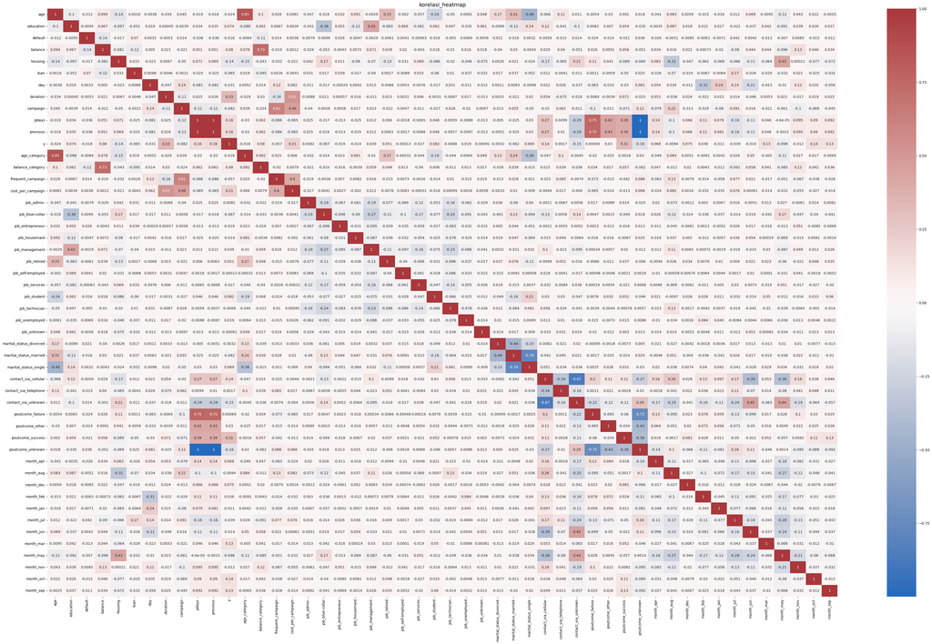

```python
#lihat korelasi antar fitur
plt.figure(figsize=(50,30))
heatmap = sns.heatmap(dftrain.corr(), annot = True, cmap = 'vlag')
heatmap.set_title("korelasi_heatmap", fontdict={'fontsize':15})
```

Koefisien kolerasi antar fitur, beberapa memiliki kolerasi yang sangat signifikan sehingga salah satu fitur tersebut akan dihapus dari model untuk menghindari overfitting.\ kolom yang akan di drop :\ pdays corr 1\ previous corr -1\ balance category 0.73\ marital status married -0.78\ contact via unknown 0.87\ poutcome unknown

```python
dftrain = dftrain.drop([ 'pdays', 'previous','balance_category', 'marital_status_single', 'contact_via_unknown', 'poutcome_unknown'], axis = 1)
```

# Modelling

```python
dftrain.head()
```

|  | age | education | default | balance | housing | loan | day | duration | campaign | y | ... | month_dec | month_feb | month_jan | month_jul | month_jun | month_mar | month_may | month_nov | month_oct | month_sep |
| --- | --- | --- | --- | --- | --- | --- | --- | --- | --- | --- | --- | --- | --- | --- | --- | --- | --- | --- | --- | --- | --- |
| 0 | 0.844028 | 2 | 0 | 0.538427 | 1 | 0 | 0.197761 | 0.666926 | 0.0 | 0 | ... | 0 | 0 | 0 | 0 | 0 | 0 | 1 | 0 | 0 | 0 |
| 1 | 0.644753 | 1 | 0 | 0.404942 | 1 | 0 | 0.197761 | 0.551671 | 0.0 | 0 | ... | 0 | 0 | 0 | 0 | 0 | 0 | 1 | 0 | 0 | 0 |
| 2 | 0.437235 | 1 | 0 | 0.401277 | 1 | 1 | 0.197761 | 0.407077 | 0.0 | 0 | ... | 0 | 0 | 0 | 0 | 0 | 0 | 1 | 0 | 0 | 0 |
| 3 | 0.692332 | 3 | 0 | 0.504183 | 1 | 0 | 0.197761 | 0.447315 | 0.0 | 0 | ... | 0 | 0 | 0 | 0 | 0 | 0 | 1 | 0 | 0 | 0 |
| 4 | 0.437235 | 3 | 0 | 0.401089 | 0 | 0 | 0.197761 | 0.608744 | 0.0 | 0 | ... | 0 | 0 | 0 | 0 | 0 | 0 | 1 | 0 | 0 | 0 |

5 rows × 44 columns

Import Library

```python
import pandas as pd
# Split data
from sklearn.model_selection import train_test_split
# Evaluasi Model
from sklearn.model_selection import cross_validate, StratifiedKFold, cross_val_predict
# Model
from sklearn.linear_model import LogisticRegression
from sklearn.ensemble import RandomForestClassifier
from sklearn.tree import DecisionTreeClassifier
from sklearn.svm import SVC
# Hyperparameter Tuning
from sklearn.model_selection import GridSearchCV
from sklearn.metrics import precision_score, recall_score, roc_auc_score,f1_score
# Predict FP/FN
from sklearn.metrics import confusion_matrix
```

## 1.Train Test Split

4521

```python
X = dftrain.drop(columns="y")
y = dftrain["y"]

X_train, X_test, y_train, y_test = train_test_split(X, y, test_size=0.1, stratify=y, random_state=42)
X_train.shape, X_test.shape, y_train.shape, y_test.shape
```

```
((37792, 43), (4200, 43), (37792,), (4200,))
```

```python
X_test['y'] = y_test
```

Visualisasi Data Test sebelum di modelling

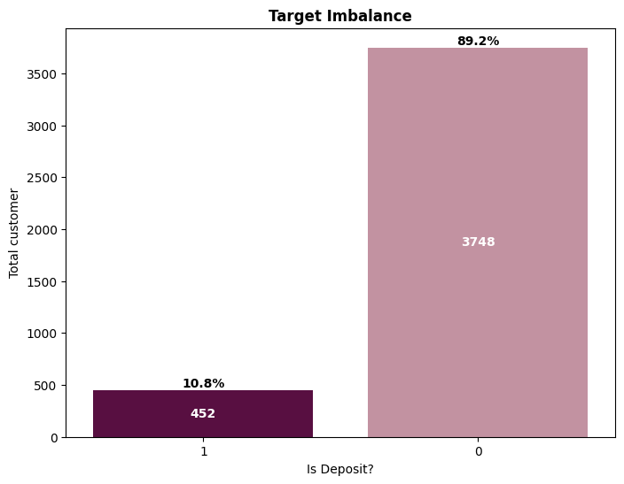

```python
y_order = [1,0]
total_data = len(X_test['y'])
colors = {0: '#c292a1', 1: '#580f41'}
plt.figure(figsize = (8,6))
ax = sns.countplot(data = X_test, x = 'y', order = y_order)
plt.xlabel('Is Deposit?')
plt.ylabel('Total customer')
for i,patch in enumerate(ax.patches):
  current_color = colors[y_order[i]]
  patch.set_facecolor(current_color)
plt.title("Target Imbalance", fontweight = 'bold')
for i,patch in enumerate(ax.patches):
  percentage = '{:.1f}%'.format(100*patch.get_height()/total_data)
  total = patch.get_height()/total_data
  x = patch.get_x()+patch.get_width()/2
  y = patch.get_height()
  ax.annotate(percentage, (x,y), ha = 'center', va = 'bottom', fontweight = 'bold')
for container in ax.containers:
   ax.bar_label(container, label_type='center', fontsize=10, color = 'white', fontweight = 'bold')
```

```
y
0    13538.157583
1     3133.159750
Name: cost_per_campaign, dtype: float64
```

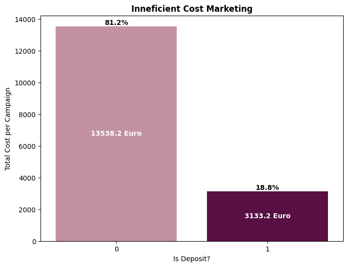

```python
cost = X_test.groupby("y")['cost_per_campaign'].sum()
total_cost = X_test['cost_per_campaign'].sum()
percentage_cost = (cost/total_cost) * 100
plot_data = pd.DataFrame({
    'label' : cost.index,
    'total cost' : cost.values,
    'percentage' : percentage_cost.values
})
plt.figure(figsize = (8,6))
print(X_test.groupby("y")['cost_per_campaign'].sum())
ax = sns.barplot(x = 'label', y = 'total cost', data = plot_data)
for i, patch in enumerate(ax.patches):
    current_color = '#580f41' if y_order[i] == 0 else '#c292a1'
    patch.set_facecolor(current_color)
plt.xlabel('Is Deposit?')
plt.ylabel('Total Cost per Campaign')
plt.title('Inneficient Cost Marketing', fontweight = 'bold')

for i, value in enumerate(plot_data['percentage']):

  plt.text(i, plot_data['total cost'][i] + 100, f'{value:.1f}%', ha='center', fontweight = 'bold')
for container in ax.containers:
   ax.bar_label(container, label_type='center', fontsize=10, fmt='%1.1f Euro', color = 'white', fontweight = 'bold')


plt.show()
```

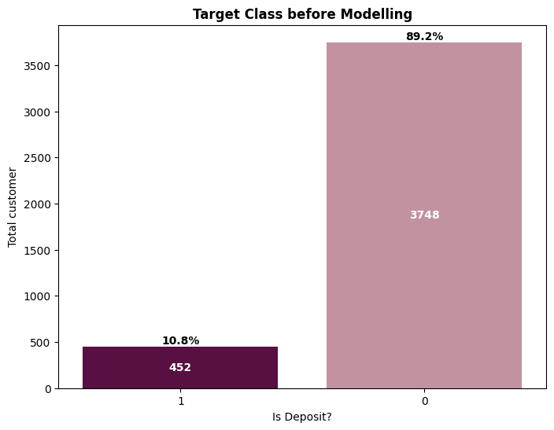

```python
y_order = [1,0]
total_data = len(X_test['y'])
colors = {0: '#c292a1', 1: '#580f41'}
plt.figure(figsize = (8,6))
ax = sns.countplot(data = X_test, x = 'y', order = y_order)
plt.xlabel('Is Deposit?')
plt.ylabel('Total customer')
for i,patch in enumerate(ax.patches):
  current_color = colors[y_order[i]]
  patch.set_facecolor(current_color)
plt.title("Target Class before Modelling", fontweight = 'bold')
for i,patch in enumerate(ax.patches):
  percentage = '{:.1f}%'.format(100*patch.get_height()/total_data)
  total = patch.get_height()/total_data
  x = patch.get_x()+patch.get_width()/2
  y = patch.get_height()
  ax.annotate(percentage, (x,y), ha = 'center', va = 'bottom', fontweight = 'bold')
for container in ax.containers:
   ax.bar_label(container, label_type='center', fontsize=10, color = 'white', fontweight = 'bold')
```

```
y
0    13538.157583
1     3133.159750
Name: cost_per_campaign, dtype: float64
```

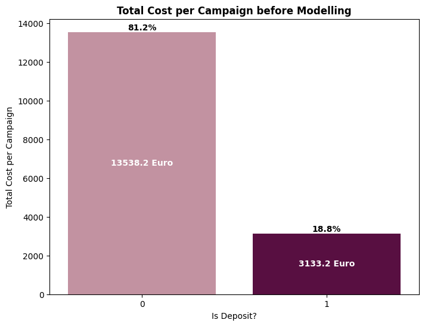

```python
cost = X_test.groupby("y")['cost_per_campaign'].sum()
total_cost = X_test['cost_per_campaign'].sum()
percentage_cost = (cost/total_cost) * 100
plot_data = pd.DataFrame({
    'label' : cost.index,
    'total cost' : cost.values,
    'percentage' : percentage_cost.values
})
plt.figure(figsize = (8,6))
print(X_test.groupby("y")['cost_per_campaign'].sum())
ax = sns.barplot(x = 'label', y = 'total cost', data = plot_data)
for i, patch in enumerate(ax.patches):
    current_color = '#580f41' if y_order[i] == 0 else '#c292a1'
    patch.set_facecolor(current_color)
plt.xlabel('Is Deposit?')
plt.ylabel('Total Cost per Campaign')
plt.title('Total Cost per Campaign before Modelling', fontweight = 'bold')

for i, value in enumerate(plot_data['percentage']):

  plt.text(i, plot_data['total cost'][i] + 100, f'{value:.1f}%', ha='center', fontweight = 'bold')
for container in ax.containers:
   ax.bar_label(container, label_type='center', fontsize=10, fmt='%1.1f Euro', color = 'white', fontweight = 'bold')


plt.show()
```

```python
X_test = X_test.drop(columns='y')
```

## 2.Evaluasi Model

```python
models = [
    ('Logistic Regression', LogisticRegression(class_weight='balanced', random_state=42)),
    ('Random Forest', RandomForestClassifier(class_weight='balanced', random_state=42)),
    ('Decision Tree', DecisionTreeClassifier(class_weight='balanced', random_state=42)),
    ('SVM', SVC(class_weight='balanced', random_state=42))
]

def train_eval_cv_model(models, X_train, y_train):
    results_cv = []
    for name, model in models:
        model.fit(X_train, y_train)
        # Cross validation (tidak pakai data test)
        stratified_kfold = StratifiedKFold(n_splits=10, shuffle=True, random_state=42)
        score = cross_validate(model, X_train, y_train, cv=stratified_kfold, scoring=['accuracy', 'precision', 'recall', 'f1', 'roc_auc'], return_train_score=True)

        result_cv = {
            'Model': name,
            'Accuracy_CV_train': score['train_accuracy'].mean(),
            'Accuracy_CV_test': score['test_accuracy'].mean(),
            'Accuracy_CV_std_test': score['test_accuracy'].std(),
            'Precision_CV_train': score['train_precision'].mean(),
            'Precision_CV_test': score['test_precision'].mean(),
            'Precision_CV_std_test': score['test_precision'].std(),
            'Recall_CV_train': score['train_recall'].mean(),
            'Recall_CV_test': score['test_recall'].mean(),
            'Recall_CV_std_test': score['test_recall'].std(),
            'F1_CV_train': score['train_f1'].mean(),
            'F1_CV_test': score['test_f1'].mean(),
            'F1_CV_std_test': score['test_f1'].std(),
            'Roc_Auc_CV_train': score['train_roc_auc'].mean(),
            'Roc_Auc_CV_test': score['test_roc_auc'].mean(),
            'Roc_Auc_CV_std_test': score['test_roc_auc'].std()
        }

        results_cv.append(result_cv)

    eval_cv = pd.DataFrame(results_cv)
    return eval_cv
```

```python
# Memanggil fungsi dan menampilkan hasilnya
evaluated_models = train_eval_cv_model(models, X_train, y_train)
print(evaluated_models)
```

[output not shown]

[output cut: 33 more lines]

[output not shown]

```
                 Model  Accuracy_CV_train  Accuracy_CV_test  \
0  Logistic Regression           0.825936          0.825466
1        Random Forest           0.999985          0.909478
2        Decision Tree           1.000000          0.884235
3                  SVM           0.820418          0.818480

   Accuracy_CV_std_test  Precision_CV_train  Precision_CV_test  \
0              0.005117            0.366137           0.365259
1              0.003493            1.000000           0.669177
2              0.004160            1.000000           0.460369
3              0.005327            0.362495           0.358848

   Precision_CV_std_test  Recall_CV_train  Recall_CV_test  Recall_CV_std_test  \
0               0.008009         0.844384        0.841903            0.021414
1               0.036929         0.999863        0.314972            0.019023
2               0.020055         1.000000        0.438173            0.021193
3               0.008210         0.881376        0.872149            0.018572

   F1_CV_train  F1_CV_test  F1_CV_std_test  Roc_Auc_CV_train  Roc_Auc_CV_test  \
0     0.510787    0.509396        0.009756           0.91114         0.909769
1     0.999932    0.428103        0.023097           1.00000         0.928434
2     1.000000    0.448878        0.019306           1.00000         0.688101
3     0.513706    0.508434        0.010319           0.91971         0.914359

   Roc_Auc_CV_std_test
0             0.007542
1             0.005381
2             0.011112
3             0.007952
```

Dari dataset ini kita ingin mengurangi False Positive, maka Metrics yang dapat kita perhatikan adalah **Precision**, selain itu, dikarenakan kita memiliki target yang imbalance maka kita juga akan memperhatikan **ROC-AUC**.

Dari ke empat model diatas, **Random Forest** menjadi model yang paling baik dari segi performa nya, berdasarkan evaluasi kita mendapatkan :\ Precision Train = 1\ Precision Test = 0.67\ ROC-AUC Train = 1\ ROC-AUC Test = 0.93

dari hasil evaluasi model diatas, kita dapatkan bahwa model tersebut masih terindikasi **Overfit**, maka kita akan melakukan **Hyper Parameter Tuning** untuk membuat model menjadi Fit/sehat

## 3.Learning Curve

```
param value: 1; train: 0.855754656574286; test: 0.8424926922677345
param value: 5; train: 0.9081921878221041; test: 0.8923036238796385
param value: 9; train: 0.9391648231630931; test: 0.9088941830923396
param value: 13; train: 0.9716054967361921; test: 0.9139045248911514
param value: 17; train: 0.9936755272098211; test: 0.9183068728100414
param value: 21; train: 0.9997136546974573; test: 0.9219619195134161
param value: 25; train: 0.9999989428372026; test: 0.9264581227982358
param value: 29; train: 1.0; test: 0.9270333558428803
param value: 33; train: 1.0; test: 0.9299865533004034
param value: 37; train: 0.9999999999999999; test: 0.9278255187427396
param value: 41; train: 1.0; test: 0.9285353368404152
param value: 45; train: 1.0; test: 0.9288664869051104
param value: 49; train: 1.0; test: 0.9288632403358488
param value: 53; train: 1.0; test: 0.9288632403358488
param value: 57; train: 1.0; test: 0.9288632403358488
param value: 61; train: 1.0; test: 0.9288632403358488
param value: 65; train: 1.0; test: 0.9288632403358488
param value: 70; train: 1.0; test: 0.9288632403358488
param value: 74; train: 1.0; test: 0.9288632403358488
param value: 78; train: 1.0; test: 0.9288632403358488
param value: 82; train: 1.0; test: 0.9288632403358488
param value: 86; train: 1.0; test: 0.9288632403358488
param value: 90; train: 1.0; test: 0.9288632403358488
param value: 94; train: 1.0; test: 0.9288632403358488
param value: 98; train: 1.0; test: 0.9288632403358488
param value: 102; train: 1.0; test: 0.9288632403358488
param value: 106; train: 1.0; test: 0.9288632403358488
param value: 110; train: 1.0; test: 0.9288632403358488
param value: 114; train: 1.0; test: 0.9288632403358488
param value: 118; train: 1.0; test: 0.9288632403358488
param value: 122; train: 1.0; test: 0.9288632403358488
param value: 126; train: 1.0; test: 0.9288632403358488
param value: 130; train: 1.0; test: 0.9288632403358488
param value: 135; train: 1.0; test: 0.9288632403358488
param value: 139; train: 1.0; test: 0.9288632403358488
param value: 143; train: 1.0; test: 0.9288632403358488
param value: 147; train: 1.0; test: 0.9288632403358488
param value: 151; train: 1.0; test: 0.9288632403358488
param value: 155; train: 1.0; test: 0.9288632403358488
param value: 159; train: 1.0; test: 0.9288632403358488
param value: 163; train: 1.0; test: 0.9288632403358488
param value: 167; train: 1.0; test: 0.9288632403358488
param value: 171; train: 1.0; test: 0.9288632403358488
param value: 175; train: 1.0; test: 0.9288632403358488
param value: 179; train: 1.0; test: 0.9288632403358488
param value: 183; train: 1.0; test: 0.9288632403358488
param value: 187; train: 1.0; test: 0.9288632403358488
param value: 191; train: 1.0; test: 0.9288632403358488
param value: 195; train: 1.0; test: 0.9288632403358488
param value: 200; train: 1.0; test: 0.9288632403358488
```

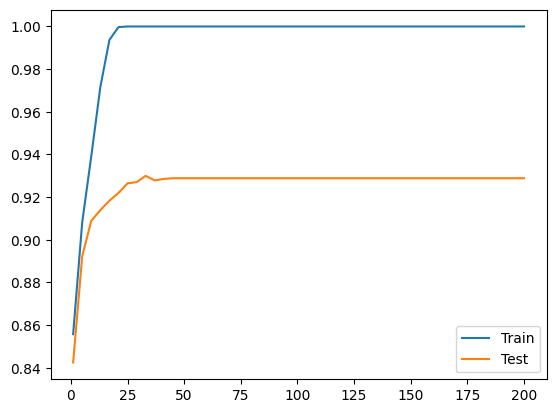

```python
#learning curve
param_values = [int(x) for x in np.linspace(1, 200, 50)] # n_estimators
# param_values = [int(x) for x in np.linspace(2, 100, 50)] # max_depth
# param_values = [int(x) for x in np.linspace(2, 20, 15)] # min_samples_split
# param_values = [int(x) for x in np.linspace(2, 20, 15)] # min_samples_leaf

train_scores = []
test_scores = []

for c in param_values:
    model = RandomForestClassifier(random_state = 42, class_weight = 'balanced', n_estimators=300, max_depth=c)
    model.fit(X_train, y_train)

    # eval on train
    y_pred_train_proba = model.predict_proba(X_train)
    train_auc = roc_auc_score(y_train, y_pred_train_proba[:,1])
    train_scores.append(train_auc)

    # eval on test
    y_pred_proba = model.predict_proba(X_test)
    test_auc = roc_auc_score(y_test, y_pred_proba[:,1])
    test_scores.append(test_auc)

    print('param value: ' + str(c) + '; train: ' + str(train_auc) + '; test: '+ str(test_auc))

plt.plot(param_values, train_scores, label='Train')
plt.plot(param_values, test_scores, label='Test')
plt.legend()
plt.show()
```

```
param value: 2; train: 0.9849457757506175; test: 0.9157468053758465
param value: 3; train: 0.9834189847846935; test: 0.9150378727061513
param value: 4; train: 0.9826734225445067; test: 0.9169019937476979
param value: 5; train: 0.9816843629035741; test: 0.9180288484241744
param value: 7; train: 0.9794491270478201; test: 0.9180341609920571
param value: 8; train: 0.9788712016641932; test: 0.9201467921534553
param value: 9; train: 0.9778764406349318; test: 0.9198486980666974
param value: 11; train: 0.9761384358328613; test: 0.9204826645007131
param value: 12; train: 0.9751036411420786; test: 0.9200411310811194
param value: 13; train: 0.9745262334036833; test: 0.9206839517949396
param value: 14; train: 0.9733891855526674; test: 0.920402975982471
param value: 16; train: 0.9724625422614499; test: 0.9216000746120645
param value: 17; train: 0.971692665276923; test: 0.9214578158498692
param value: 18; train: 0.971171374656126; test: 0.921829695601666
param value: 20; train: 0.970156425462823; test: 0.9217901464852051
```

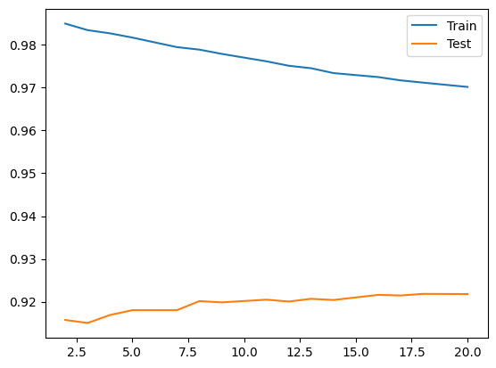

```python
#learning curve
# param_values = [int(x) for x in np.linspace(1, 200, 50)] # n_estimators
# param_values = [int(x) for x in np.linspace(2, 100, 50)] # max_depth
param_values = [int(x) for x in np.linspace(2, 20, 15)] # min_samples_split
# param_values = [int(x) for x in np.linspace(2, 20, 15)] # min_samples_leaf

train_scores = []
test_scores = []

for c in param_values:
    model = RandomForestClassifier(random_state = 42, class_weight = 'balanced', n_estimators=300, max_depth=15, min_samples_split = c)
    model.fit(X_train, y_train)

    # eval on train
    y_pred_train_proba = model.predict_proba(X_train)
    train_auc = roc_auc_score(y_train, y_pred_train_proba[:,1])
    train_scores.append(train_auc)

    # eval on test
    y_pred_proba = model.predict_proba(X_test)
    test_auc = roc_auc_score(y_test, y_pred_proba[:,1])
    test_scores.append(test_auc)

    print('param value: ' + str(c) + '; train: ' + str(train_auc) + '; test: '+ str(test_auc))

plt.plot(param_values, train_scores, label='Train')
plt.plot(param_values, test_scores, label='Test')
plt.legend()
plt.show()
```

```
param value: 2; train: 0.907500406005195; test: 0.8921123714358572
param value: 3; train: 0.9073393745934254; test: 0.8918514653242791
param value: 4; train: 0.9073544810852615; test: 0.8917800408005213
param value: 5; train: 0.90722584259976; test: 0.8917617419555917
param value: 7; train: 0.9069213213878797; test: 0.8913768759267479
param value: 8; train: 0.9069932266850491; test: 0.891509099838498
param value: 9; train: 0.9070614319124277; test: 0.8914418073119823
param value: 11; train: 0.9067220534913439; test: 0.8907865906064356
param value: 12; train: 0.9067564003460933; test: 0.8908698208365995
param value: 13; train: 0.9066631221334712; test: 0.8907452706340138
param value: 14; train: 0.9068365989031388; test: 0.8910032253189901
param value: 16; train: 0.9067156886422258; test: 0.8908751334044823
param value: 17; train: 0.9067941702210728; test: 0.8908338134320607
param value: 18; train: 0.9065536511031039; test: 0.8905941575920137
param value: 20; train: 0.906613296957212; test: 0.8907051312322325
```

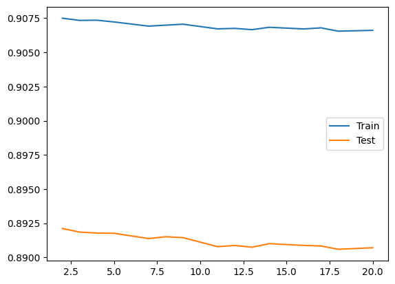

```python
#learning curve
# param_values = [int(x) for x in np.linspace(1, 200, 50)] # n_estimators
# param_values = [int(x) for x in np.linspace(2, 100, 50)] # max_depth
# param_values = [int(x) for x in np.linspace(2, 20, 15)] # min_samples_split
param_values = [int(x) for x in np.linspace(2, 20, 15)] # min_samples_leaf

train_scores = []
test_scores = []

for c in param_values:
    model = RandomForestClassifier(random_state = 42, class_weight = 'balanced', n_estimators=300, max_depth=5, min_samples_split = 40, min_samples_leaf = c)
    model.fit(X_train, y_train)

    # eval on train
    y_pred_train_proba = model.predict_proba(X_train)
    train_auc = roc_auc_score(y_train, y_pred_train_proba[:,1])
    train_scores.append(train_auc)

    # eval on test
    y_pred_proba = model.predict_proba(X_test)
    test_auc = roc_auc_score(y_test, y_pred_proba[:,1])
    test_scores.append(test_auc)

    print('param value: ' + str(c) + '; train: ' + str(train_auc) + '; test: '+ str(test_auc))

plt.plot(param_values, train_scores, label='Train')
plt.plot(param_values, test_scores, label='Test')
plt.legend()
plt.show()
```

```
param value: 2; train: 0.9026332175497045; test: 0.8884620470150452
param value: 3; train: 0.9026332175497045; test: 0.8884620470150452
param value: 4; train: 0.9026332175497045; test: 0.8884620470150452
param value: 5; train: 0.9026332175497045; test: 0.8884620470150452
param value: 7; train: 0.9026332175497045; test: 0.8884620470150452
param value: 8; train: 0.9026332175497045; test: 0.8884620470150452
param value: 9; train: 0.9026332175497045; test: 0.8884620470150452
param value: 11; train: 0.9026332175497045; test: 0.8884620470150452
param value: 12; train: 0.9026332175497045; test: 0.8884620470150452
param value: 13; train: 0.9026332175497045; test: 0.8884620470150452
param value: 14; train: 0.9026332175497045; test: 0.8884620470150452
param value: 16; train: 0.9026332175497045; test: 0.8884620470150452
param value: 17; train: 0.9026332175497045; test: 0.8884620470150452
param value: 18; train: 0.9026332175497045; test: 0.8884620470150452
param value: 20; train: 0.9026332175497045; test: 0.8884620470150452
```

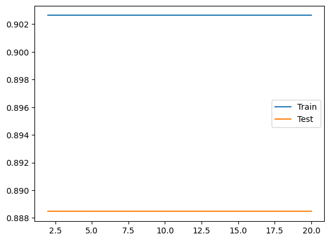

```python
#learning curve
# param_values = [int(x) for x in np.linspace(1, 200, 50)] # n_estimators
# param_values = [int(x) for x in np.linspace(2, 100, 50)] # max_depth
# param_values = [int(x) for x in np.linspace(2, 20, 15)] # min_samples_split
# param_values = [int(x) for x in np.linspace(2, 20, 15)] # min_samples_leaf

train_scores = []
test_scores = []

for c in param_values:
    model = RandomForestClassifier(random_state = 42, class_weight = 'balanced', n_estimators=300, max_depth=5, min_samples_split = 40, min_samples_leaf = 150)
    model.fit(X_train, y_train)

    # eval on train
    y_pred_train_proba = model.predict_proba(X_train)
    train_auc = roc_auc_score(y_train, y_pred_train_proba[:,1])
    train_scores.append(train_auc)

    # eval on test
    y_pred_proba = model.predict_proba(X_test)
    test_auc = roc_auc_score(y_test, y_pred_proba[:,1])
    test_scores.append(test_auc)

    print('param value: ' + str(c) + '; train: ' + str(train_auc) + '; test: '+ str(test_auc))

plt.plot(param_values, train_scores, label='Train')
plt.plot(param_values, test_scores, label='Test')
plt.legend()
plt.show()
```

## 4.Hyper Parameter Tuning

```python
# Buat objek model Random Forest Classifier
rf = RandomForestClassifier(random_state = 42, class_weight = 'balanced')

# Daftar parameter yang ingin Anda uji dan distribusi acaknya
param = {
    'n_estimators': [300],
    'criterion' : ['entropy'],
    'max_depth': [15],
    'min_samples_split' : [40],
    'max_features': ['log2'],
    'min_samples_leaf': [150]
}

# Inisialisasi RandomizedSearchCV
gridsearch = GridSearchCV(rf,
                          param,
                          scoring='roc_auc',
                          cv=5,
                          n_jobs=-1,
                          verbose=1
                          )

# Lakukan Randomized Cross-Validation pada data pelatihan
gridsearch.fit(X_train, y_train)

# Tampilkan parameter terbaik dan skor kinerja terbaik
best_params = gridsearch.best_params_
print("Parameter Terbaik:", gridsearch.best_params_)
print("Skor Terbaik:", gridsearch.best_score_)
print("Skor data train:", gridsearch.score(X_train, y_train))
best_model = gridsearch.best_estimator_
print(best_model)
prediction = best_model.predict(X_test)
best_rf_model = RandomForestClassifier(**best_params, class_weight = 'balanced')
best_rf_model.fit(X_train, y_train)
```

```
Fitting 5 folds for each of 1 candidates, totalling 5 fits
Parameter Terbaik: {'criterion': 'entropy', 'max_depth': 15, 'max_features': 'log2', 'min_samples_leaf': 150, 'min_samples_split': 40, 'n_estimators': 300}
Skor Terbaik: 0.9070695748609963
Skor data train: 0.9181018459702868
RandomForestClassifier(class_weight='balanced', criterion='entropy',
                       max_depth=15, max_features='log2', min_samples_leaf=150,
                       min_samples_split=40, n_estimators=300, random_state=42)
```

```
RandomForestClassifier(class_weight='balanced', criterion='entropy',
                       max_depth=15, max_features='log2', min_samples_leaf=150,
                       min_samples_split=40, n_estimators=300)
```

```python
pd.Series(prediction).value_counts()
```

```
0    3047
1    1153
dtype: int64
```

## 5.Feature Importance

```python
!pip install shap
```

```
     ━━━━━━━━━━━━━━━━━━━━━━━━━━━━━━━━━━━━━━━━ 532.9/532.9 kB 7.8 MB/s eta 0:00:00
```

```python
import shap
```

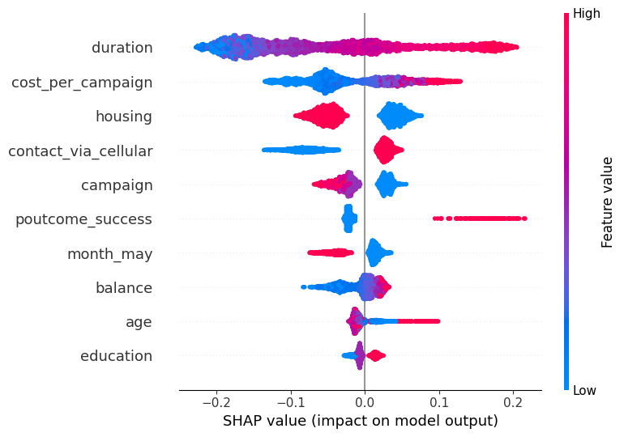

```python
# Inisialisasi model Random Forest Classifier dengan parameter terbaik
# 'max_depth': 20, 'max_features': 'auto', 'min_samples_leaf': 1, 'n_estimators': 300}

best_rf = RandomForestClassifier(
    class_weight = 'balanced',
    criterion = 'entropy',
    random_state=42,
    n_estimators=300,
    min_samples_leaf=150,
    min_samples_split=40,
    max_features='log2',
    max_depth=15
)
# Latih model pada data pelatihan
best_rf.fit(X_train, y_train)

# Hitung feature importance menggunakan SHAP
explainer = shap.TreeExplainer(best_rf)
shap_values = explainer.shap_values(X_test)
# Munculkan summary plot feature importance
shap.summary_plot(shap_values[1], X_test, max_display=10)
```

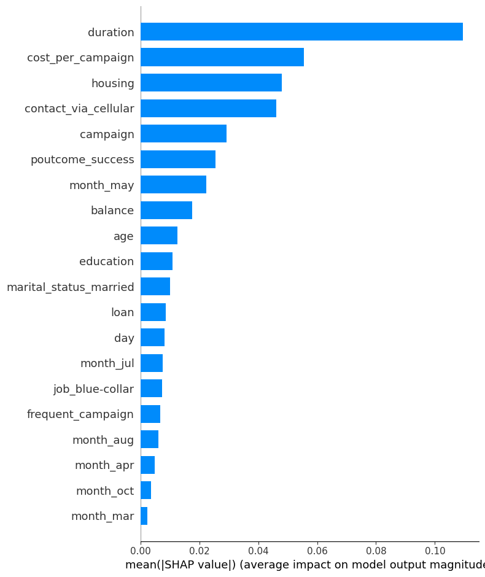

```python
shap.summary_plot(shap_values[1], X_test, plot_type="bar")
```